# Prediction Assignment Writeup

Geetha

6 December 2016

# Synopsis:

Using devices such as Jawbone Up, Nike FuelBand, and Fitbit it is now possible to collect a large amount of data about personal activity relatively inexpensively. These type of devices are part of the quantified self movement – a group of enthusiasts who take measurements about themselves regularly to improve their health, to find patterns in their behavior, or because they are tech geeks. One thing that people regularly do is quantify how much of a particular activity they do, but they rarely quantify how well they do it. In this project, the goal will be to use data from accelerometers on the belt, forearm, arm, and dumbell of 6 participants to predict the manner in which they did the exercise. They were asked to perform barbell lifts correctly and incorrectly in 5 different ways.

# Data

The training data is available here: https://d396qusza40orc.cloudfront.net/predmachlearn/pml-training.csv The test data is available here:https://d396qusza40orc.cloudfront.net/predmachlearn/pml-testing.csv

The data is downloaded from the above link and uploaded here as train data and test data. All the missing values were replaced with NA. To enable reproducability the seed has been set.

```r
set.seed(123)
train_data <- read.csv(file.path("D:/Geetha/Coursera/R/Assignment 6/pml-training.csv"), na.strings = c("NA","#DIV/0!", ""))
test_data <- read.csv(file.path("D:/Geetha/Coursera/R/Assignment 6/pml-testing.csv"),na.strings = c("NA","#DIV/0!", ""))
```

# Libraries

Download the necessary libraries

```r
library(caret)
library(randomForest)
```

```r
library(rpart)
library(rpart.plot)
library(rattle)
```

On further analysis of the data, many columns were found which didnt have any values.Those columns were deleted to have a meaningful data. There are currently 19622 observations in train data and 20 observations in test data.

```r
train_data <- train_data[, colSums(is.na(train_data))==0]
test_data <- test_data[, colSums(is.na(test_data))==0]

dim(train_data);dim(test_data)
```

```
## [1] 19622    60
```

```
## [1] 20 60
```

# Cross validation

To enable cross validation, the training data is now split into train_data1 and test_data1

```r
split <- createDataPartition(y = train_data$classe, p = 0.75, list = FALSE)
train_data1 <- train_data[split, ]
test_data1 <- train_data[-split, ]
dim(train_data1);dim(test_data1)
```

```
## [1] 14718    60
```

```
## [1] 4904   60
```

The manner in which the exercise was performed is available in the column “classe”. There are five different fashions - exactly according to the specification (Class A), throwing the elbows to the front (Class B), lifting the dumbbell only halfway (Class C), lowering the dumbbell only halfway (Class D) and throwing the hips to the front (Class E). The goal of this exercise is to predict the manner (“classe”) in which the exercise was performed.

# Prediction Model 1 - Decision Tree

The first model used for prediction is Decision Tree.

```r
dt <- rpart(classe~., data = train_data1[, -c(1:7)], method = "class")
predict2 <- predict(dt, test_data1, type = "class")

CMR1 <- confusionMatrix(predict2, test_data1$classe)
CMR1
```

```
## Confusion Matrix and Statistics
##
##           Reference
## Prediction    A    B    C    D    E
##          A 1277  187   16   97   28
##          B   36  512   68   28   51
##          C   36   95  694  138  121
##          D   20   69   54  490   49
##          E   26   86   23   51  652
##
## Overall Statistics
##
##                Accuracy : 0.7392
##                  95% CI : (0.7267, 0.7514)
##     No Information Rate : 0.2845
##     P-Value [Acc > NIR] : < 2.2e-16
##
##                   Kappa : 0.6685
##  Mcnemar's Test P-Value : < 2.2e-16
##
## Statistics by Class:
##
##                      Class: A Class: B Class: C Class: D Class: E
## Sensitivity            0.9154   0.5395   0.8117  0.60945   0.7236
## Specificity            0.9065   0.9537   0.9037  0.95317   0.9535
## Pos Pred Value         0.7956   0.7367   0.6402  0.71848   0.7780
## Neg Pred Value         0.9642   0.8962   0.9579  0.92563   0.9388
## Prevalence             0.2845   0.1935   0.1743  0.16395   0.1837
## Detection Rate         0.2604   0.1044   0.1415  0.09992   0.1330
## Detection Prevalence   0.3273   0.1417   0.2210  0.13907   0.1709
## Balanced Accuracy      0.9110   0.7466   0.8577  0.78131   0.8386
```

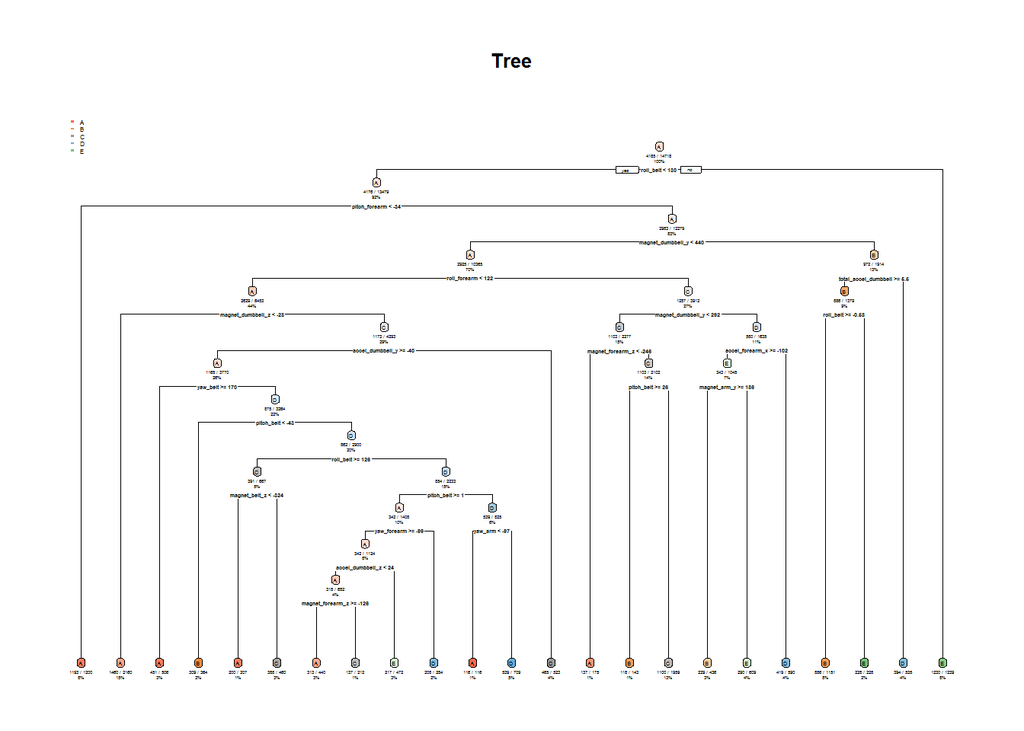

```r
rpart.plot(dt, main = "Tree", extra = 102, under = TRUE, faclen = 0)
```

Result:

The accuracy from this prediction model is 0.739.